# Hand-on3

Mingjie Ye

12/15/2018

## Goal

To practice named entity recognition using lexical-syntactic patterns.

## Tasks

- Recognize entities Define lexical-syntactic patterns using regular expressions to detect person names
- Assess approach Check the results of your patterns using metrics
- Answer question Which patterns have worked better? Which worse?

## Preparation

With the help of the [code provided by professors](https://rpubs.com/rgcmme/IS-HO3), we loaded libraies and files, defined some auxiliary functions, and annotated corpus.

## Define Patterns

Firstly, we defined some simple string patterns to try to identify people appearances and detected those patterns in the corpus.

```r
pattern0=c("created by")
pattern0=c(pattern0,"screenwriter[s]?")
pattern0=c(pattern0,"cinematographer")
pattern0=c(pattern0,"oscar winner")
matches0 = detectPatternsInCorpus(corpus, pattern0)
matches0[!is.na(matches0[3]),c(1,3)]
```

```
##                File screenwriter[s]?
## 1   cv000_29590.txt    screenwriters
## 29  cv028_26746.txt    screenwriters
## 30  cv029_18643.txt     screenwriter
## 77  cv076_24945.txt     screenwriter
## 79  cv078_14730.txt     screenwriter
## 87  cv086_18371.txt     screenwriter
## 95  cv094_27889.txt    screenwriters
## 116 cv115_25396.txt     screenwriter
## 122 cv121_17302.txt     screenwriter
## 136 cv135_11603.txt    screenwriters
## 143 cv142_22516.txt     screenwriter
## 144 cv143_19666.txt     screenwriter
## 159 cv158_10390.txt     screenwriter
## 163 cv162_10424.txt     screenwriter
```

[output cut: 70 more lines]

To check how many patterns we have found in each file.

```r
countMatchesPerRow(matches0)
```

```
##                File Count
## 1   cv000_29590.txt     4
## 29  cv028_26746.txt     1
## 30  cv029_18643.txt     1
## 68  cv067_19774.txt     1
## 77  cv076_24945.txt     1
## 79  cv078_14730.txt     1
## 87  cv086_18371.txt     1
## 95  cv094_27889.txt     1
## 100 cv099_10534.txt     1
## 109 cv108_15571.txt     1
## 116 cv115_25396.txt     1
## 122 cv121_17302.txt     2
## 136 cv135_11603.txt     1
## 143 cv142_22516.txt     1
```

[output cut: 119 more lines]

To check how many times each pattern has been found.

```r
countMatchesPerColumn(matches0)
```

```
##             Entity Count
## 1       created by     9
## 2 screenwriter[s]?    84
## 3  cinematographer    42
## 4     oscar winner     8
```

## Find entities

In this section, we defined two patterns to recognize entities.

### Pattern 1

Pattern 1 used regular expressions.

```r
pattern1=c("created by ([A-z]* [A-z]*)")
pattern1=c(pattern1,"created by [A-z]* [A-z]* \\( and ([A-z]* [A-z]*)")
pattern1=c(pattern1,"screenwriter[s]? ([A-z]* [A-z]*)")
pattern1=c(pattern1,"cinematographer(?: ,)? ([A-z]* [A-z]*)")
pattern1=c(pattern1,"oscar winner ([A-z]* [A-z]*)")
matches1 = detectPatternsInCorpus(corpus, pattern1)
matches1[!is.na(matches1[4]),c(1,4)]
```

```
##                File screenwriter[s]? ([A-z]* [A-z]*)
## 1   cv000_29590.txt                      terry hayes
## 29  cv028_26746.txt                          are the
## 30  cv029_18643.txt                      alex proyas
## 77  cv076_24945.txt                    toby emmerich
## 79  cv078_14730.txt                          to dumb
## 87  cv086_18371.txt                   frank cottrell
## 95  cv094_27889.txt                    james schamus
## 116 cv115_25396.txt                karey kirkpatrick
## 122 cv121_17302.txt                         can make
## 144 cv143_19666.txt                               j
## 159 cv158_10390.txt                     paul rudnick
## 163 cv162_10424.txt                      amongst the
## 179 cv178_12972.txt                          for the
## 191 cv190_27052.txt                           of the
```

[output cut: 55 more lines]

```r
# printMatchesPerPattern(pattern1, matches1)
```

To check how many patterns we have found in each file.

```r
countMatchesPerRow(matches1)
```

```
##                File Count
## 1   cv000_29590.txt     5
## 29  cv028_26746.txt     1
## 30  cv029_18643.txt     1
## 68  cv067_19774.txt     1
## 77  cv076_24945.txt     1
## 79  cv078_14730.txt     1
## 87  cv086_18371.txt     1
## 95  cv094_27889.txt     1
## 100 cv099_10534.txt     1
## 109 cv108_15571.txt     1
## 116 cv115_25396.txt     1
## 122 cv121_17302.txt     2
## 144 cv143_19666.txt     1
## 155  cv154_9328.txt     1
```

[output cut: 100 more lines]

To check how many times each pattern has been found.

```r
countMatchesPerColumn(matches1)
```

```
##                                             Entity Count
## 1                       created by ([A-z]* [A-z]*)     8
## 2 created by [A-z]* [A-z]* \\( and ([A-z]* [A-z]*)     1
## 3                 screenwriter[s]? ([A-z]* [A-z]*)    69
## 4           cinematographer(?: ,)? ([A-z]* [A-z]*)    40
## 5                     oscar winner ([A-z]* [A-z]*)     5
```

### Pattern 2

Pattern 2 used part-of-speech (POS) tags.

```r
pattern2=c("created/VBN by/IN ([A-z]*)/NN ([A-z]*)/NN")
pattern2=c(pattern2,"created/VBN by/IN [A-z]*/NN [A-z]*/NN \\(/-LRB- and/CC ([A-z]*)/JJ ([A-z]*)/NN")
pattern2=c(pattern2,"screenwriter[s]?/NN[S]? ([A-z]*)/(?:NN[S]?|JJ) ([A-z]*)/(?:NN|JJ)")
pattern2=c(pattern2,"cinematographer/NN(?: ,/,)? ([A-z]*)/NN ([A-z]*)/NN")
pattern2=c(pattern2,"cinematographer/NN(?: ,/,)? ([A-z]*)/NN ([A-z]*)/IN ([A-z]*)/NN")
pattern2=c(pattern2,"oscar/NN winner/NN ([A-z]*)/VBG ([A-z]*)/NNS")
allEntities = detectPatternsInTaggedCorpus(corpus, corpus.taggedText, pattern2)
allEntities[!is.na(allEntities[4]),c(1,4)]
```

```
##                File
## 1   cv000_29590.txt
## 30  cv029_18643.txt
## 77  cv076_24945.txt
## 87  cv086_18371.txt
## 95  cv094_27889.txt
## 116 cv115_25396.txt
## 192 cv191_29719.txt
## 226 cv225_29224.txt
## 242 cv241_23130.txt
## 275 cv274_25253.txt
## 433 cv432_14224.txt
## 453  cv452_5088.txt
## 465 cv464_15650.txt
## 477 cv476_16856.txt
```

[output cut: 41 more lines]

We could view the entities for a certain pattern.

```r
Filter(Negate(is.na),allEntities[[4]])
```

```
##  [1] " terry hayes"       " alex proyas"       " toby emmerich"
##  [4] " frank cottrell"    " james schamus"     " karey kirkpatrick"
##  [7] " marc klein"        " andy breckman"     " ehren kruger"
## [10] " karey kirkpatrick" " david goyer"       " larry ferguson"
## [13] " john eskow"        " david duncan"      " elizabeth jane"
## [16] " mark christopher"  " mary harron"       " scott b"
## [19] " john hodge"        " marc norman"       " lawrence wright"
## [22] " john august"       " jeffrey reddick"   " glen morgan"
## [25] " dana stevens"      " rafael yglesias"   " steven gevedon"
```

```r
printMatchesPerPattern(pattern2, allEntities)
```

```
## [1] "PATTERN:  created/VBN by/IN ([A-z]*)/NN ([A-z]*)/NN"
## [1] " alan moore"     " fluid dynamics" " edgar rice"
## [1] " "
## [1] "PATTERN:  created/VBN by/IN [A-z]*/NN [A-z]*/NN \\(/-LRB- and/CC ([A-z]*)/JJ ([A-z]*)/NN"
## [1] " eddie campbell"
## [1] " "
## [1] "PATTERN:  screenwriter[s]?/NN[S]? ([A-z]*)/(?:NN[S]?|JJ) ([A-z]*)/(?:NN|JJ)"
##  [1] " terry hayes"       " alex proyas"       " toby emmerich"
##  [4] " frank cottrell"    " james schamus"     " karey kirkpatrick"
##  [7] " marc klein"        " andy breckman"     " ehren kruger"
## [10] " karey kirkpatrick" " david goyer"       " larry ferguson"
## [13] " john eskow"        " david duncan"      " elizabeth jane"
## [16] " mark christopher"  " mary harron"       " scott b"
## [19] " john hodge"        " marc norman"       " lawrence wright"
## [22] " john august"       " jeffrey reddick"   " glen morgan"
```

[output cut: 18 more lines]

We count all the entities per pattern.

```r
entityCountPerPattern = countMatchesPerColumn(allEntities)
entityCountPerPattern
```

```
##                                                                           Entity
## 1                                      created/VBN by/IN ([A-z]*)/NN ([A-z]*)/NN
## 2 created/VBN by/IN [A-z]*/NN [A-z]*/NN \\(/-LRB- and/CC ([A-z]*)/JJ ([A-z]*)/NN
## 3              screenwriter[s]?/NN[S]? ([A-z]*)/(?:NN[S]?|JJ) ([A-z]*)/(?:NN|JJ)
## 4                            cinematographer/NN(?: ,/,)? ([A-z]*)/NN ([A-z]*)/NN
## 5                cinematographer/NN(?: ,/,)? ([A-z]*)/NN ([A-z]*)/IN ([A-z]*)/NN
## 6                                   oscar/NN winner/NN ([A-z]*)/VBG ([A-z]*)/NNS
##   Count
## 1     3
## 2     1
## 3    27
## 4    22
## 5     1
## 6     1
```

And we can also draw a histogram of the counts.

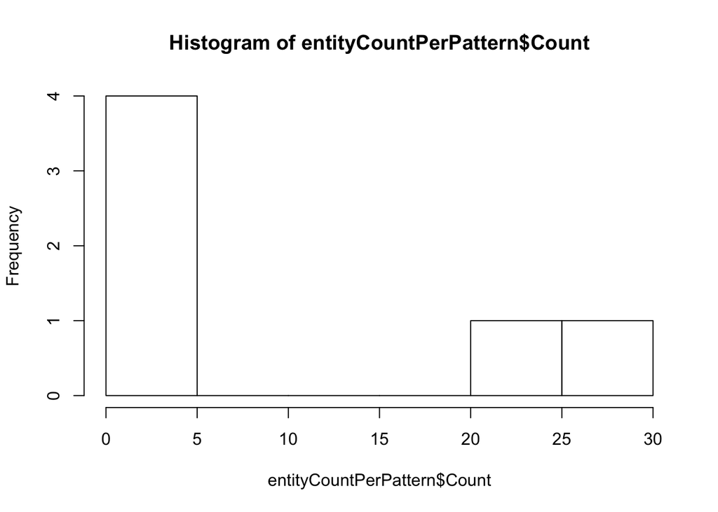

```r
hist(entityCountPerPattern$Count)
```

We count all the entities per file.

```r
entityCountPerFile=countMatchesPerRow(allEntities)
entityCountPerFile
```

```
##                File Count
## 1   cv000_29590.txt     5
## 30  cv029_18643.txt     1
## 68  cv067_19774.txt     1
## 77  cv076_24945.txt     1
## 87  cv086_18371.txt     1
## 95  cv094_27889.txt     1
## 100 cv099_10534.txt     1
## 116 cv115_25396.txt     1
## 122 cv121_17302.txt     1
## 155  cv154_9328.txt     1
## 192 cv191_29719.txt     1
## 216 cv215_22240.txt     1
## 226 cv225_29224.txt     1
## 242 cv241_23130.txt     1
```

[output cut: 35 more lines]

And we can also draw a histogram of the counts.

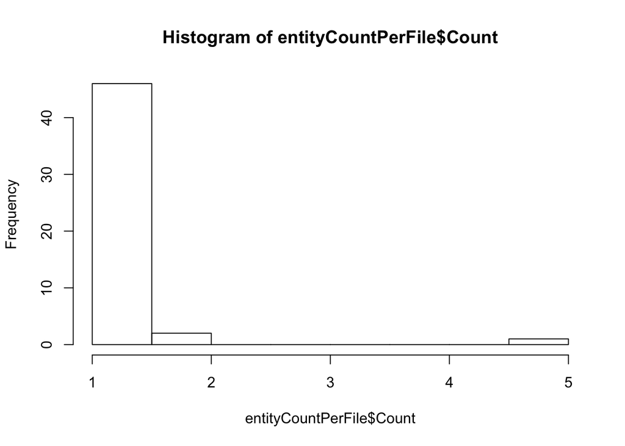

```r
hist(entityCountPerFile$Count)
```

## Write

```r
write.table(allEntities, file = "allEntities.csv", row.names = F, na="", sep=";")
```

## Evaluation

We compared the results of two patterns with a gold standard.

```r
allMatches = mergeAllMatchesInLists(allEntities)
head(allMatches)
```

```
##             Files
## 1 cv000_29590.txt
## 2 cv001_18431.txt
## 3 cv002_15918.txt
## 4 cv003_11664.txt
## 5 cv004_11636.txt
## 6 cv005_29443.txt
##                                                                     Matches
## 1  alan moore,  eddie campbell,  terry hayes,  peter deming,  martin childs
## 2                                                                      NULL
## 3                                                                      NULL
## 4                                                                      NULL
## 5                                                                      NULL
## 6                                                                      NULL
```

```r
goldStandard = read.table(file = "goldStandard.csv", quote = "", na.strings=c(""),
                          colClasses="character", sep=";")
allMatchesGold = mergeGoldStandardInLists(goldStandard)
head(allMatchesGold)
```

```
##             Files
## 1 cv000_29590.txt
## 2 cv001_18431.txt
## 3 cv002_15918.txt
## 4 cv003_11664.txt
## 5 cv004_11636.txt
## 6 cv005_29443.txt
##                                                                                                                                                                                                                                                                                                          …
## 1 alan moore, eddie campbell, moore, campbell, jack, michael jackson, albert, allen hughes, peter godley, robbie coltrane, frederick abberline, johnny depp, abberline, mary kelly, heather graham, terry hayes, rafael yglesias, steve guttenberg, tim burton, marilyn manson, peter deming, martin chil…
## 2                                                                                                                                                 matthew broderick, reese witherspoon, george washington carver, tracy flick, paul, max fischer, bill murray, broderick, witherspoon, jessica campbell, …
## 3                                                                                                                                                                                                                                                                                   ryan, hanks, tom hank…
## 4                                                                          john williams, steven spielberg, spielberg, williams, martin brody, roy scheider, larry vaughn, murray hamilton, brody, matt hooper, richard dreyfuss, hooper, vaughn, quint, robert shaw, hitchcock, scheider, dreyfuss, shaw…
## 5                                                                                                                                                                                                                    herb, jackie chan, barry sanders, sanders, jackie, chan, bruce lee, tim allen, lawre…
## 6                                                                                                                                                                                             raoul peck, lumumba, patrice lumumba, eriq ebouaney, helmer peck, peck, pascal bonitzer, patrice, joseph ka…
```

```r
# metrix of pattern 1
allMatches1 = mergeAllMatchesInLists(matches1)
metrics1 = calculateMetrics(allMatches1, allMatchesGold)
metrics1
```

```
##   Precision      Recall   Fmeasure
## 1 0.5609756 0.005167378 0.01024043
```

And the metrix of pattern 2:

```r
metrics2 = calculateMetrics(allMatches, allMatchesGold)
metrics2
```

```
##   Precision      Recall    Fmeasure
## 1 0.8181818 0.003370029 0.006712411
```